# Text Mining - Ejercicio 1

Jean-Paul Beaudry

Sunday 05 May, 2019

# 1 Text Analytics de Twitter

- Entra en **Rstudio Cloud** en el proyecto de **Text-Mining**.
- Usa **TextMiningTwitter1.R** para crear un nuevo .Rmd en el que resolver este ejercicio.
- **Antes de terminar la clase, descarga de Rstudio Cloud el .Rmd con lo que te haya dado tiempo a hacer y súbelo a la tarea correspondiente a este ejercicio en el CV.**
- Termina en casa el ejercicio y súbelo en tarea para este ejercicio del tema de Text-Mining.
- Los alumnos que realicen este ejercicio adecuadamente no tendrán que hacer ningún ejercicio de este tema en el control de junio. Se dará una lista en el CV.
- Realiza el siguiente Análisis de Twitter:
- Introduce tus claves en el documento para conectar con Twitter. Antes del final de la clase, elíminalas del .Rmd cuando ya no te hagan falta.

# 2 Extraer de Twitter los tweets referentes a **#CambioClimático.**

```r
setup_twitter_oauth(CONSUMER_KEY, CONSUMER_SECRET, access_token, access_secret)
```

```
## [1] "Using direct authentication"
```

```r
hashtag = "#CambioClimatico"
tweets <- twitteR::searchTwitter(hashtag, n=5000, lang="es")
```

# 3 Pasa los tweets a un dataframe y visualiza la cabeza del data frame.

```r
tweets.df = ldply(tweets, function(t) t$toDataFrame())
head(tweets.df) %>%
  select(screenName, text) %>%
  datatable(style = 'bootstrap', options = list(pageLength=page.length))
```

|  | screenName | text |
| --- | --- | --- |
| 1 | LOLA97030229 | RT @sombradoble: Hoy es el #DiaDeLaMadre y es nuestra costumbre contar historias tiernas con osos polares, este año también hay osos pero |
| 2 | guadabril | Nos estamos cargando el y nos da igual, cuando nos queramos darnos cuenta será demasiado tarde. En menos de 2km d https://t.co/FrDECCJQoo |
| 3 | BettyHuertas3 | RT @tikopineda: @MiguelSandova1_ @petrogustavo El desafío de la humanidad es despetrolizar y descarbonizar la economía incluyendo un cambio |
| 4 | antgargon96 | RT @EQUORM: Intervención de nuestra Candidata Regional @Helena_314 esta mañana, porque una Región que Cuida de todas las Personas de una m |
| 5 | Pasescoon | RT @EQUORM: Intervención de nuestra Candidata Regional @Helena_314 esta mañana, porque una Región que Cuida de todas las Personas de una m |
| 6 | LaPublicacion | Esto es lo que ocurriría si se derritiera todo el hielo del planeta #CambioClimático https://t.co/TsczAIzQKd |

# 4 Graba los tweets en un csv.

```r
write.csv(tweets.df, file = "cambioclimatico.csv ")
```

# 5 ¿Cuantos tweets hay?

```r
nrow(tweets.df)
```

```
## [1] 5000
```

# 6 ¿Cuantos usuarios distintos han participado?

```r
length(unique(tweets.df$screenName))
```

```
## [1] 3347
```

# 7 ¿Cuantos tweets son re-tweets?

```r
length(which(tweets.df$isRetweet))
```

```
## [1] 3341
```

# 8 ¿Cuantos tweets han sido re-tweeteados?

```r
length(which(tweets.df$retweeted))
```

```
## [1] 0
```

# 9 ¿Cuál es el número medio de retweets?

```r
mean(tweets.df$retweetCount, na.rm=TRUE)
```

```
## [1] 52.7132
```

# 10 Da una lista con los distintos idiomas que se han usado al twitear este hashtag.

La columna *language* no se encuentra presente en los datos obtenidos de Twitter.

```r
names(tweets.df)
```

```
##  [1] "text"          "favorited"     "favoriteCount" "replyToSN"
##  [5] "created"       "truncated"     "replyToSID"    "id"
##  [9] "replyToUID"    "statusSource"  "screenName"    "retweetCount"
## [13] "isRetweet"     "retweeted"     "longitude"     "latitude"
```

# 11 Encontrar los nombres de usuarios de las 10 personas que más han participado. ¿Quién es el usuario que más ha participado?

```r
tweets.df %>%
  dplyr::group_by(screenName) %>%
  dplyr::summarize(count = n()) %>%
  dplyr::arrange(desc(count)) %>%
  head(10) %>%
  datatable(style = 'bootstrap', options = list(pageLength=page.length))
```

|  | screenName | count |
| --- | --- | --- |
| 1 | pieldeatun | 35 |
| 2 | iSostenibilidad | 24 |
| 3 | 100CoNeutral | 19 |
| 4 | jesusdelaosa | 18 |
| 5 | jochanto | 18 |
| 6 | tierra_los | 15 |
| 7 | concienciaeco | 14 |
| 8 | DebesLeerlo | 13 |
| 9 | ensgismau | 13 |
| 10 | lado_mx | 13 |

```r
tweets.df %>%
  dplyr::group_by(screenName) %>%
  dplyr::summarize(count = n()) %>%
  dplyr::arrange(desc(count)) %>%
  head(1) %>%
  datatable(style = 'bootstrap')
```

|  | screenName | count |
| --- | --- | --- |
| 1 | pieldeatun | 35 |

# 12 Extraer en un data frame aquellos tweets re-tuiteados más de 5 veces

```r
retweets.df <- tweets.df %>%
  dplyr::filter(retweetCount > 5)

retweets.df %>%
  select(screenName, text) %>%
  datatable(style = 'bootstrap', options = list(pageLength=page.length))
```

|  | screenName | text |
| --- | --- | --- |
| 1 | LOLA97030229 | RT @sombradoble: Hoy es el #DiaDeLaMadre y es nuestra costumbre contar historias tiernas con osos polares, este año también hay osos pero |
| 2 | antgargon96 | RT @EQUORM: Intervención de nuestra Candidata Regional @Helena_314 esta mañana, porque una Región que Cuida de todas las Personas de una m |
| 3 | Pasescoon | RT @EQUORM: Intervención de nuestra Candidata Regional @Helena_314 esta mañana, porque una Región que Cuida de todas las Personas de una m |
| 4 | PacoJ_gmez | RT @mitecogob: Los pequeños cambios contra el #CambioClimatico son grandes si los hacemos todos. @ONU_es ha identificado 10 acciones |
| 5 | jpalopcasado | RT @iSostenibilidad: Esto es lo que está pasando....no es tan difícil de entender #CambioClimatico @blogsostenible @sostenible132 @agorarsc |
| 6 | VamosFueguinos | RT @CMNUCC: La Tierra es nuestro único hogar. Este vídeo es un poderoso recordatorio de la necesidad urgente de emprender la #AcciónClimáti |
| 7 | NoInvisibles | RT @sombradoble: Hoy es el #DiaDeLaMadre y es nuestra costumbre contar historias tiernas con osos polares, este año también hay osos pero |
| 8 | jlieberman1 | RT @MauricioAdmPub: La Sierra Nevada de Santa Marta tenía en 1950 un poco más de 82 km2 de Nieves Perpetuas, hoy tiene menso de 7 km2 #Cam |
| 9 | AmaleeAmin | RT @melania_guerra: "Si bien las evidencias que avalan el #CambioClimatico y sus consecuencias vienen de la #ciencia, lo que se decide o no |
| 10 | ASDEN_Soria | RT @iSostenibilidad: Expertos en seguros sitúan el #CambioClimático cómo riesgo número 1 para el 2019 https://t.co/DtcGef3KqA |

[output cut: 2767 more lines]

# 13 Aplicarle a los tweets las técnicas de Text-Mining vistas en clase:

## 13.1 Haz pre-procesamiento adecuado.

```r
tweets.df$text <- stringr::str_replace_all(tweets.df$text, "@\\w+"," ")
tweets.df$text <- stringr::str_replace_all(tweets.df$text, "#\\S+"," ")## Remove Hashtags
tweets.df$text <- stringr::str_replace_all(tweets.df$text, "http\\S+\\s*"," ")## Remove URLs
tweets.df$text <- stringr::str_replace_all(tweets.df$text, "http[[:alnum:]]*"," ")## Remove URLs
tweets.df$text <- stringr::str_replace_all(tweets.df$text, "http[[\\b+RT]]"," ")## Remove URLs
tweets.df$text <- stringr::str_replace_all(tweets.df$text, "[[:cntrl:]]"," ")
tweets.df$text <- stringr::str_replace_all(tweets.df$text, hashtag," ")
tweets.df$text <- stringr::str_replace_all(tweets.df$text, "skeptical","escépticos")
tweets.df$text <- stringr::str_replace_all(tweets.df$text, "[^[:alnum:]]", " ")
tweets.df$text <- removeWords(tweets.df$text, stopwords("spanish"))
tweets.df$text <- removeWords(tweets.df$text, c("rt"))
tweets.df$text <- stripWhitespace(tweets.df$text)
tweets.df$text <- stringr::str_replace_all(tweets.df$text, "[\U00010000-\U0010ffff]", "")
tweets.df$text <- chartr("áéóúí", "aeoui", tweets.df$text)
tweets.df$text <- gsub('[[:punct:] ]+',' ',tweets.df$text)
tweets.df$text <- gsub('[[:digit:] ]+',' ',tweets.df$text)
tweets.df$text <- sapply(tweets.df$text, function(x) tolower(x))

twt.corpus <- Corpus(VectorSource(tweets.df$text))

dtm <- DocumentTermMatrix(twt.corpus)
dtm
```

```
## <<DocumentTermMatrix (documents: 5000, terms: 4099)>>
## Non-/sparse entries: 38653/20456347
## Sparsity           : 100%
## Maximal term length: 20
## Weighting          : term frequency (tf)
```

## 13.2 Calcula la media de la frecuencia de aparición de los términos

```r
freq <- colSums(as.matrix(dtm))

freq.dt <- as.data.frame(freq)
freq.dt$termino <- row.names(freq.dt)
row.names(freq.dt) <- 1:NROW(freq.dt)

#Vuelvo a quitar los stopwords dado que siguen apareciendo algunos.
freq.dt$termino = removeWords(freq.dt$termino, stopwords("spanish"))
freq.dt <- freq.dt[!freq.dt$termino == "",]

freq.mean <- mean(freq.dt$freq); freq.mean
```

```
## [1] 9.112075
```

## 13.3 Encuentra los términos que ocurren más de la media y guárdalos en un data.frame: término y su frecuencia.

```r
over.mean <- freq.dt[freq.dt$freq > freq.mean,]

over.mean %>%
  arrange(termino) %>%
  datatable(style = 'bootstrap', options = list(pageLength=page.length))
```

|  | freq | termino |
| --- | --- | --- |
| 1 | 13 | abarca |
| 2 | 10 | abrigos |
| 3 | 16 | abril |
| 4 | 28 | absurdo |
| 5 | 11 | accion |
| 6 | 108 | acciones |
| 7 | 10 | acompañamos |
| 8 | 10 | actividades |
| 9 | 19 | actua |
| 10 | 15 | actual |

[output cut: 725 more lines]

## 13.4 Ordena este data.frame por la frecuencia.

```r
over.mean %>%
  arrange(desc(freq)) %>%
  datatable(style = 'bootstrap', options = list(pageLength=page.length))
```

|  | freq | termino |
| --- | --- | --- |
| 1 | 369 | climatica |
| 2 | 344 | derretimiento |
| 3 | 299 | emergencia |
| 4 | 298 | tierra |
| 5 | 293 | urgente |
| 6 | 291 | glaciares |
| 7 | 288 | necesidad |
| 8 | 286 | hogar |
| 9 | 285 | video |
| 10 | 283 | unico |

[output cut: 725 more lines]

## 13.5 Haz un plot de los términos más frecuentes.

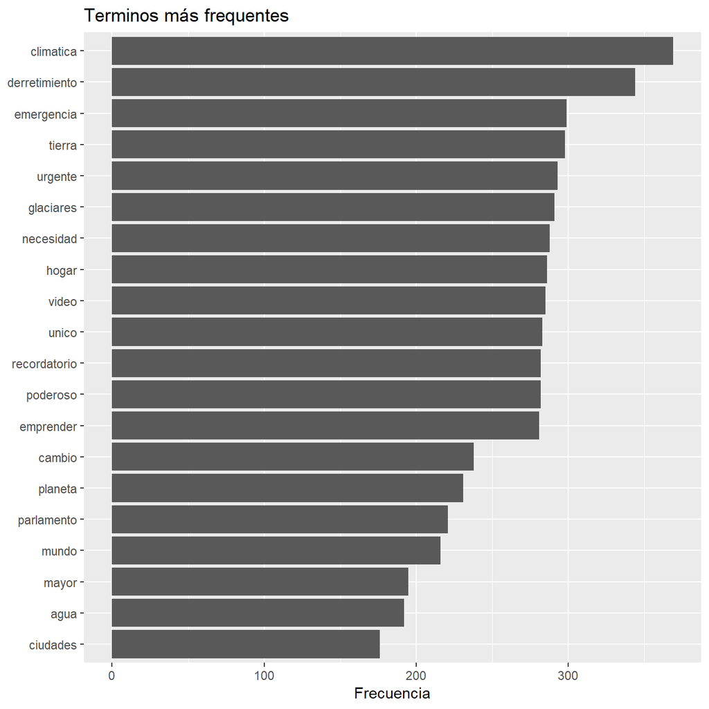

```r
over.mean %>%
  arrange(desc(freq)) %>%
  head(20) %>%
  mutate(termino = reorder(termino, freq)) %>%
  ggplot(aes(termino, freq)) +
  geom_col(show.legend = TRUE) +
  labs(x=NULL, y="Frecuencia") +
  coord_flip()+
  ggtitle("Terminos más frequentes")
```

## 13.6 Genera diversos wordclouds y graba en disco el wordcloud generado.

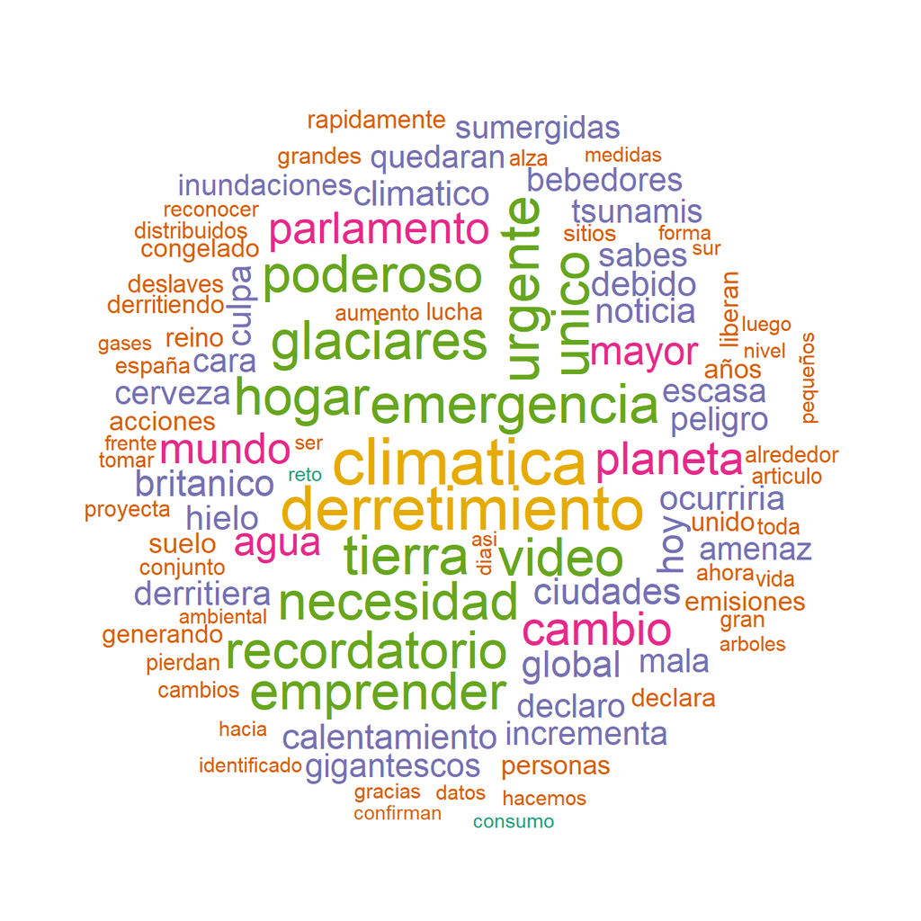

```r
wordcloud(freq.dt$termino, freq.dt$freq, scale=c(3,0.5),
          max.words=100, random.order=FALSE,
          rot.per=0.10, use.r.layout=TRUE,
          colors=brewer.pal(6, "Dark2"))
```

## 13.7 Busca información de paquete wordcloud2. Genera algún gráfico con este paquete.

Para que las gráficas de `wordcloud2` funcionen necesitan un data.frame estructurado de la siguiente forma.

```r
head(demoFreq)
```

```
##          word freq
## oil       oil   85
## said     said   73
## prices prices   48
## opec     opec   42
## mln       mln   31
## the       the   26
```

Por tanto, debemos reestructurar el `data.frame` para que funcione.

```r
top100 <- over.mean %>%arrange(desc(freq)) %>% head(100)
row.names(top100) <- top100$termino
colnames(top100) <- c("freq","word")
top100 <- top100 %>% select(word, everything())
wordcloud2(top100)
```

[interactive chart not shown]

# 14 Para las 5 palabras más importantes de vuestro análisis encontrar palabras que estén relacionadas y guárdalas en un data.frame. Haz plot de las asociaciones.

```r
top.words <- freq.dt %>% arrange(desc(freq)) %>% head(5); top.words
```

```
##   freq       termino
## 1  369     climatica
## 2  344 derretimiento
## 3  299    emergencia
## 4  298        tierra
## 5  293       urgente
```

```r
tdm <- TermDocumentMatrix(twt.corpus); tdm
```

```
## <<TermDocumentMatrix (terms: 4099, documents: 5000)>>
## Non-/sparse entries: 38653/20456347
## Sparsity           : 100%
## Maximal term length: 20
## Weighting          : term frequency (tf)
```

```r
assocs <- findAssocs(dtm, top.words$termino, 0.5)

assocs.list <- lapply(assocs, function(x) data.frame(rhs = names(x), cor = x, stringsAsFactors = F))

assocs.df <- dplyr::bind_rows(assocs.list, .id = "lhs")

assocs.df  %>%
  datatable(style = 'bootstrap', options = list(pageLength=page.length))
```

|  | lhs | rhs | cor |
| --- | --- | --- | --- |
| 1 | climatica | parlamento | 0.7 |
| 2 | climatica | amenaz | 0.61 |
| 3 | climatica | britanico | 0.61 |
| 4 | climatica | declaro | 0.61 |
| 5 | climatica | sabes | 0.6 |
| 6 | climatica | porque | 0.58 |
| 7 | climatica | mayor | 0.53 |
| 8 | derretimiento | glaciares | 0.91 |
| 9 | derretimiento | gigantescos | 0.64 |
| 10 | derretimiento | incrementa | 0.64 |

[output cut: 33 more lines]

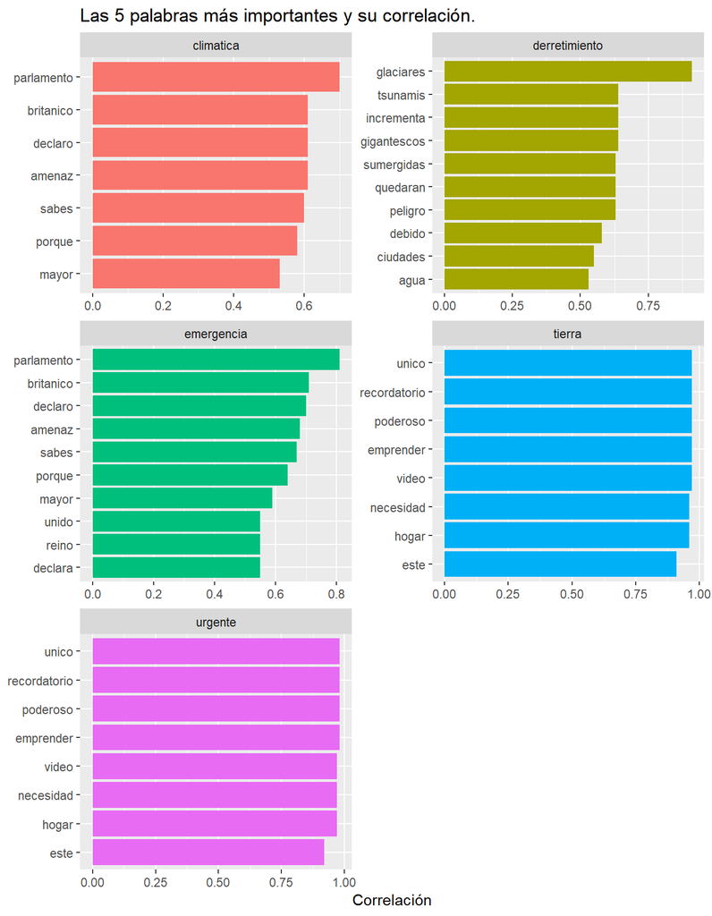

```r
assocs.df %>%
  group_by(lhs) %>%
  top_n(15, cor) %>%
  ungroup() %>%
  mutate(rhs = reorder(rhs, cor)) %>%
  ggplot(aes(rhs, cor, fill=lhs)) +
  geom_col(show.legend = F) +
  coord_flip() +
  facet_wrap(~lhs,ncol=2, scales="free") +
  ggtitle("Las 5 palabras más importantes y su correlación.") +
  labs(x=NULL, y="Correlación")
```

# 15 Haz plot con los dispositivos desde los que se han mandado los tweets.

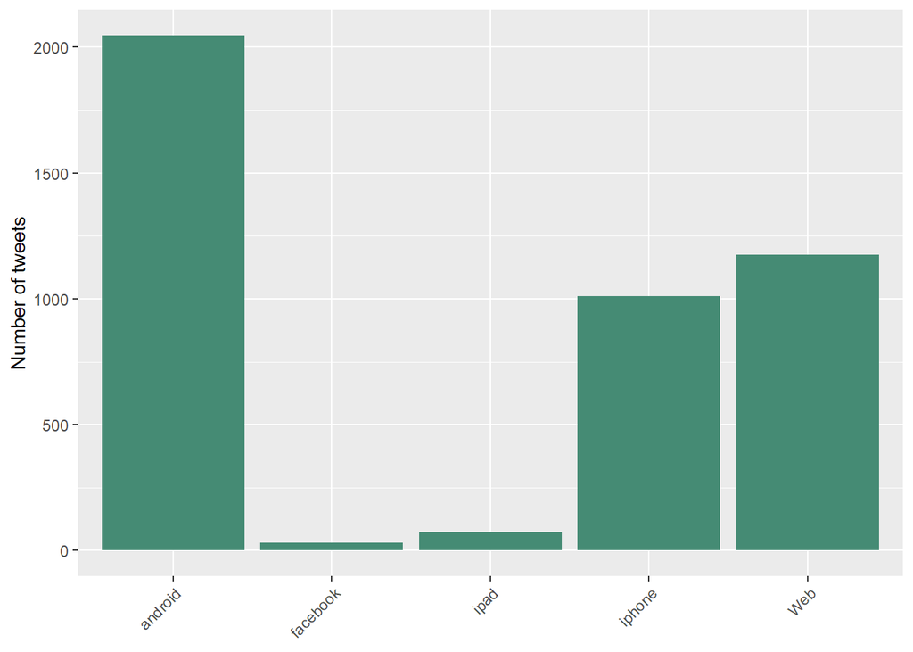

```r
encodeSource <- function(x) {
  if(x=="<a href=\"http://twitter.com/download/iphone\" rel=\"nofollow\">Twitter for iPhone</a>"){
    gsub("<a href=\"http://twitter.com/download/iphone\" rel=\"nofollow\">Twitter for iPhone</a>", "iphone", x,fixed=TRUE)
  }else if(x=="<a href=\"http://twitter.com/#!/download/ipad\" rel=\"nofollow\">Twitter for iPad</a>"){
    gsub("<a href=\"http://twitter.com/#!/download/ipad\" rel=\"nofollow\">Twitter for iPad</a>","ipad",x,fixed=TRUE)
  }else if(x=="<a href=\"http://twitter.com/download/android\" rel=\"nofollow\">Twitter for Android</a>"){
    gsub("<a href=\"http://twitter.com/download/android\" rel=\"nofollow\">Twitter for Android</a>","android",x,fixed=TRUE)
  } else if(x=="<a href=\"http://twitter.com\" rel=\"nofollow\">Twitter Web Client</a>"){
    gsub("<a href=\"http://twitter.com\" rel=\"nofollow\">Twitter Web Client</a>","Web",x,fixed=TRUE)
  } else if(x=="<a href=\"http://www.twitter.com\" rel=\"nofollow\">Twitter for Windows Phone</a>"){
    gsub("<a href=\"http://www.twitter.com\" rel=\"nofollow\">Twitter for Windows Phone</a>","windows phone",x,fixed=TRUE)
  }else if(x=="<a href=\"http://dlvr.it\" rel=\"nofollow\">dlvr.it</a>"){
    gsub("<a href=\"http://dlvr.it\" rel=\"nofollow\">dlvr.it</a>","dlvr.it",x,fixed=TRUE)
  }else if(x=="<a href=\"http://ifttt.com\" rel=\"nofollow\">IFTTT</a>"){
    gsub("<a href=\"http://ifttt.com\" rel=\"nofollow\">IFTTT</a>","ifttt",x,fixed=TRUE)
  }else if(x=="<a href=\"http://earthquaketrack.com\" rel=\"nofollow\">EarthquakeTrack.com</a>"){
    gsub("<a href=\"http://earthquaketrack.com\" rel=\"nofollow\">EarthquakeTrack.com</a>","earthquaketrack",x,fixed=TRUE)
  }else if(x=="<a href=\"http://www.didyoufeel.it/\" rel=\"nofollow\">Did You Feel It</a>"){
    gsub("<a href=\"http://www.didyoufeel.it/\" rel=\"nofollow\">Did You Feel It</a>","did_you_feel_it",x,fixed=TRUE)
  }else if(x=="<a href=\"http://www.mobeezio.com/apps/earthquake\" rel=\"nofollow\">Earthquake Mobile</a>"){
    gsub("<a href=\"http://www.mobeezio.com/apps/earthquake\" rel=\"nofollow\">Earthquake Mobile</a>","earthquake_mobile",x,fixed=TRUE)
  }else if(x=="<a href=\"http://www.facebook.com/twitter\" rel=\"nofollow\">Facebook</a>"){
    gsub("<a href=\"http://www.facebook.com/twitter\" rel=\"nofollow\">Facebook</a>","facebook",x,fixed=TRUE)
  }else {
    "others"
  }
}

tweets.df$tweetSource = sapply(tweets.df$statusSource,
                               function(sourceSystem) encodeSource(sourceSystem))

ggplot(tweets.df[tweets.df$tweetSource != 'others',], aes(tweetSource)) +
  geom_bar(fill = "aquamarine4") +
  theme(legend.position="none",
        axis.title.x = element_blank(),
        axis.text.x = element_text(angle = 45, hjust = 1)) +
  ylab("Number of tweets")
```

# 16 Para la palabra más frecuente de tu análisis busca y graba en un data.frame en los tweets en los que está dicho término. El data.frame tendrá como columnas: término, usuario, texto.

```r
top.word <- freq.dt %>% arrange(desc(freq)) %>% head(1); top.word
```

```
##   freq   termino
## 1  369 climatica
```

```r
results <- tweets.df %>%
  filter(str_detect(text, top.word$termino)) %>%
  select(screenName, text) %>%
  mutate(`término` = top.word$termino, usuario = screenName, texto = text) %>%
  select(`término`, usuario, texto)

results %>%
  datatable(style = 'bootstrap', options = list(pageLength=page.length))
```

|  | término | usuario | texto |
| --- | --- | --- | --- |
| 1 | climatica | Lnitacs | rt declara emergencia climatica se convierte primer gran pais reconocer amenaza real |
| 2 | climatica | SalvemosLV_Educ | rt ahora momento reconocer urgencia climatica enfrentamos tomar medidas altura reto |
| 3 | climatica | JosBaena52 | rt y luego dicen cuento chino bienvenidos pesadilla climatica indonesia tr |
| 4 | climatica | deutsfer | rt ahora momento reconocer urgencia climatica enfrentamos tomar medidas altura reto |
| 5 | climatica | TSOsolar | reino unido primer pais reconocer formalmente emergencia climatica juntos podem |
| 6 | climatica | teresav55694568 | rt reino unido declara emergencia climatica desde luego objetivo proponen cero emisiones |
| 7 | climatica | Jhon_Unchupaico | rt sabes parlamento britanico declaro emergencia climatica porque mayor amenaz |
| 8 | climatica | ureingenieria | rt sabes parlamento britanico declaro emergencia climatica porque mayor amenaz |
| 9 | climatica | jovenesingSCI | rt sabes parlamento britanico declaro emergencia climatica porque mayor amenaz |
| 10 | climatica | lexambientalcq | rt sabes parlamento britanico declaro emergencia climatica porque mayor amenaz |

[output cut: 362 more lines]

Back to top